# Rejection Sampling-Gamma

Jingjing Guo

November 14, 2017

## Generate gamma random variable via rejection sampling

### Unit Uniform to Exponential with $\lambda$:

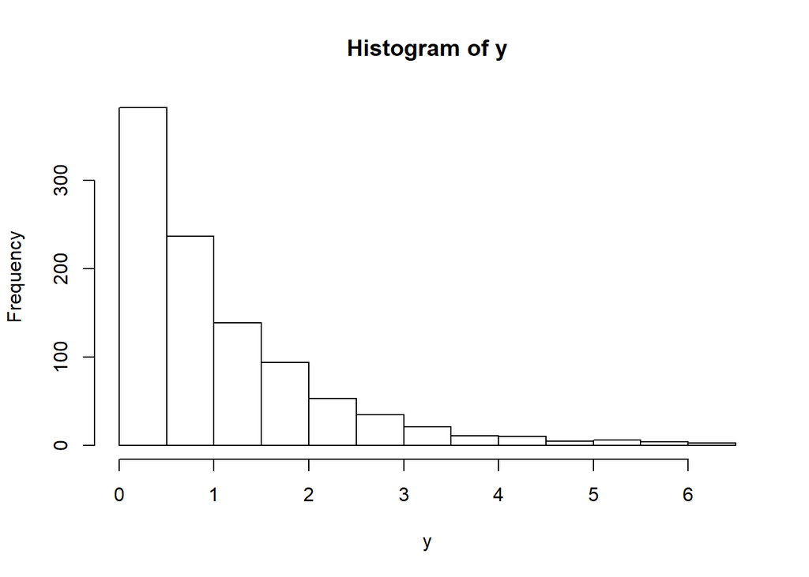

```r
lambda <- 1
x <- runif(1000)
y <- -1/lambda *log(1-x)
hist(y)
```

The inverse-cdf method: The CDF of a random variable, X, is denoted as F(x), and $U \sim UNIF(0,1)$, then X can be generated by:
$$\begin{align*}
X = F^{-1}(U)
\end{align*}$$

Proof: The CDF of a random variable, X, is defined as: F(X) = $Pr(X \leq x)$ Assume random variable Y is a function of X, i.e. $Y = g(X)$ then $X = g^{-1}(Y)$, therefore

$$\begin{align*}
Pr(X \leq x) = Pr( g^{-1} (Y) \leq x)
\end{align*}$$
Note the event $g^{-1} (Y) \leq x$ is equivalent to $g ( g^{-1} (Y) ) \leq g(x)$ that is
$$\begin{align*}
Pr( g^{-1} (Y) \leq x) &= Pr\{ g(g^{-1} (Y)) \leq g(x) \} \\ &= Pr\{ Y \leq g(x) \}
\end{align*}$$
For unit uniform distributions $Pr(Y \leq y) = y$ and so if $Y \sim UNIF(0,1)$, then
$$\begin{align*}
Pr(X \leq x) &= Pr( g^{-1} (Y) \leq x) \\ &= Pr\{ g(g^{-1} (Y)) \leq g(x) \} \\ &= Pr\{ Y \leq g(x) \} \\ &= g(x)
\end{align*}$$

Therefore $y = g(x) = F(x)$, $x = F^{-1}(y)$, where $y \sim UNIF(0,1)$

### Truncated Pareto distribution:

#### normalization constants:

$K = 1- a$

$$\begin{align*}
1 &= \int_0^1 P(Y=y) dy = \int_0^1 K \frac{1}{y^a} dy = \left. \frac{K}{1-a} y^{1-a} \right \rvert_0^1 = \frac{K}{1-a}\\
1 &= \frac{K}{1-a}
\end{align*}$$

therefore the normalizing constant is $K = 1-a$.

#### inverse-cdf method to generate Y by transforming U:

Probability density function of Y is:
$$\begin{align*}
Y = f(y) &= K \frac{1}{y^a} = (1-a) \frac{1}{y^a} \\
\end{align*}$$
Cumulative density function of Y is then:
$$\begin{align*}
F(y) &= \int_0^y (1-a) \frac{1}{y^a} dy = y^{1-a}\\
Y &= F^{-1}(U) = U^{(a-1)}
\end{align*}$$